# Adapting the epidemiological model.

Edwin van Leeuwen

2020-01-14

# Introduction

This vignette shows how to re-implement the SEEIIR model used in the package using the [`odin` ODE solver package](https://github.com/richfitz/odin). You can use this vignette to learn more on how the current model works and how to make changes to the current model.

In the package the transmission model is implemented in the `infectionODEs` function, which is called as follows:

```r
infectionODEs(population, initial_infected, vaccine_calendar, contact_matrix,
  susceptibility, transmissibility, infection_delays, interval)
```

For more details on the built-in function see the [modelling vignette](https://blackedder.github.io/flu-evidence-synthesis/modelling.html).

## Epidemiological model

The epidemiological model implemented in the package is an SEIR model, with two compartments for the Exposed and Infectious states that result in a more realistic gamma distributed average time for both the Exposed and Infectious states (rather than an exponentially distributed waiting time when there is only a single compartment). The general model has the following form.
$$\begin{equation}\begin{split}
\frac{dS_{ik}}{dt} & = -\lambda_i S_{ik} \\
\frac{dE_{ik}^1}{dt} & = \lambda_i S_{ik} -\gamma_1 E_{ik}^1 \\
\frac{dE_{ik}^2}{dt} & = \gamma_1 \left(E_{ik}^1 -E_{ik}^2 \right) \\
\frac{dI_{ik}^1}{dt} & = \gamma_1 E_{ik}^2 -\gamma_2 I_{ik}^1 \\
\frac{dI_{ik}^2}{dt} & = \gamma_2 \left( I_{ik}^1 - I_{ik}^2 \right) \\
\frac{dR_{ik}}{dt} & = \gamma_2 I_{ik}^2
\end{split}\end{equation}$$
where $S_{ik}$ is the number of susceptibles in the age group $i$ and risk group $k$, $E_{ik}^1$ and $E_{ik}^2$ are two compartments with exposed but not yet infectious individuals of age group $i$ and risk group $k$, $I_{ik}^1$ and $I_{ik}^2$ represent infectious individuals, and immune individuals of age group $i$ and risk group $k$ are given by $R_{ik}$. The rate of loss of latency and infectiousness are respectively $\gamma_1$ and $\gamma_2$, while the age-group-specific force of infection $\lambda_i$ is given by
$$\begin{equation}
\lambda_i = \sigma_i \sum_{j=1}^x \sum_{k=1}^y \beta_{i,j} \left( I_{ik}^1 + I_{ik}^2 \right)
\end{equation}$$
where $\beta_{i,j}$ is the effective contact rate between individuals in age group $i$ and age group $j$, and $\sigma_i$ is the susceptibility of the age group $i$ (that can be inferred from serological data).

Eq. 1 tracks the infection for each age and risk group. To implement vaccination in the package we further separate each of the epidemiological compartments (SEEIIR) in the model (1) into vaccinated and non-vaccinated group. Non-vaccinated people of age $i$ and risk $k$ are vaccinated at a given rate ($\mu_{ik}$) regardless of their epidemiological status. If the subject has already been exposed or infected, the infection progresses as normal. Depending on the efficacy of the vaccine ($\alpha$), a proportion of vaccinated susceptibles will become immune ($\mu_{ik} \alpha S$), so the total rate of becoming vaccinated and recovered is $\mu_{ik} ( R+\alpha S)$. If the vaccine isn’t 100% effective, a proportion of vaccinated individuals will remain susceptible so the rate of becoming a ‘vaccinated susceptible’ is $\mu_{ik} (1-\alpha) S$. For full details of the underlying model see the supplementary information of Baguelin et al. (2013).

We will be implementing this epidemiological model using the odin package. For installation and usage instructions we refer to their [website](https://github.com/richfitz/odin). The model definition in odin is shown below. Note that you need to make sure you have installed and loaded (`library(odin)`) the odin package before running this code.

```r
gen_seeiir_ag_vacc <- odin::odin({
  # Number of groups
  no_groups <- user()

  # INITIAL CONDITIONS
  # Population size by age/risk group
  pop[] <- user()
  # Initial infection by age/risk group
  I0[] <- user()

  # MODEL PARAMETERS
  # Susceptibility
  susc[] <- user()

  # Transmissibility
  trans <- user()

  # Latent periods
  gamma1 <- user()
  gamma2 <- user()

  # Vaccine related variables
  dates[] <- user()
  calendar[,] <- user()

  # efficacy
  alpha[] <- user()

  # Contact matrix
  cij[,] <- user()

  # Force of infection
  lambda[] <- trans * susc[i] * (sum(sij[i,]))

  # Vaccination. The rate is a step function that changes at each date according
  # to the passed calendar
  vI[] <- interpolate(dates, calendar, "constant")
  # Vaccination is given as a fraction vaccination, here we scale it to
  # a rate
  sumN[] <- if (vI[i]>0) (S[i]+E1[i]+E2[i]+I1[i]+I2[i]+R[i]) else 0
  v[] <- if (sumN[i]>0) vI[i]*pop[i]/sumN[i] else 0

  # Transmission matrix
  sij[,] <- cij[i,j] * (I1[j] + I2[j] + I1v[j] + I2v[j])

  # Newly infected
  newInf[] <- lambda[i] * S[i]
  newInfv[] <- lambda[i] * Sv[i]

  # THE DERIVATIVES OF THE SEEIIR MODEL
  # Derivatives of the not vaccinated group
  deriv(S[]) <- -newInf[i] - v[i] * S[i]
  deriv(E1[]) <- newInf[i] - gamma1 * E1[i] - v[i] * E1[i]
  deriv(E2[]) <- gamma1 * (E1[i] - E2[i]) - v[i] * E2[i]
  deriv(I1[]) <- gamma1 * E2[i]  - gamma2 * I1[i] - v[i] * I1[i]
  deriv(I2[]) <- gamma2 * (I1[i] - I2[i]) - v[i] * I2[i]
  deriv(R[]) <- gamma2 * I2[i] - v[i] * R[i]

  # Derivatives vaccination group
  deriv(Sv[]) <- -newInfv[i] + v[i] * (1-alpha[i]) * S[i]
  deriv(E1v[]) <- newInfv[i] - gamma1 * E1v[i] + v[i] * E1[i]
  deriv(E2v[]) <- gamma1 * (E1v[i] - E2v[i]) + v[i] * E2[i]
  deriv(I1v[]) <- gamma1 * E2v[i]  - gamma2 * I1v[i] + v[i] * I1[i]
  deriv(I2v[]) <- gamma2 * (I1v[i] - I2v[i]) + v[i] * I2[i]
  deriv(Rv[]) <- gamma2 * I2v[i] + v[i] * (R[i] + alpha[i] * S[i])

  # Tracking the cumulative amount of infections over time for output of incidence
  deriv(cumI[]) <- newInf[i] + newInfv[i]

  # Initial value of the variables
  initial(S[1:no_groups]) <- pop[i] - I0[i]
  initial(E1[1:no_groups]) <- 0
  initial(E2[1:no_groups]) <- 0
  initial(I1[1:no_groups]) <- I0[i]
  initial(I2[1:no_groups]) <- 0
  initial(R[1:no_groups]) <- 0
  initial(cumI[1:no_groups]) <- 0

  initial(Sv[1:no_groups]) <- 0
  initial(E1v[1:no_groups]) <- 0
  initial(E2v[1:no_groups]) <- 0
  initial(I1v[1:no_groups]) <- 0
  initial(I2v[1:no_groups]) <- 0
  initial(Rv[1:no_groups]) <- 0

  # Set dimension of all variables/parameters
  dim(dates) <- user()
  dim(calendar) <- user()

  dim(pop) <- no_groups
  dim(I0) <- no_groups
  dim(susc) <- no_groups
  dim(lambda) <- no_groups
  dim(v) <- no_groups
  dim(vI) <- no_groups
  dim(sumN) <- no_groups
  dim(alpha) <- no_groups
  dim(cij) <- c(no_groups, no_groups)
  dim(sij) <- c(no_groups, no_groups)

  dim(S) <- no_groups
  dim(E1) <- no_groups
  dim(E2) <- no_groups
  dim(I1) <- no_groups
  dim(I2) <- no_groups
  dim(R) <- no_groups
  dim(Sv) <- no_groups
  dim(E1v) <- no_groups
  dim(E2v) <- no_groups
  dim(I1v) <- no_groups
  dim(I2v) <- no_groups
  dim(Rv) <- no_groups
  dim(cumI) <- no_groups
  dim(newInf) <- no_groups
  dim(newInfv) <- no_groups
}, verbose = F)
```

In the above code we “flatten” the age/risk group so that we can more easily represent the population in one vector. What this means is that instead of having an matrix for each state ($S; E1; E2; \dots$) with the age groups on one dimension and the risk groups on the other dimension, we transform these into a vector, with first all the age groups for the first risk group, followed by the age groups for the second risk group, and so on.

Next we write a helper function `infection_odin`, which has the same inputs and outputs as the `infectionODEs` function and wraps the above implemented odin model (`gen_seeiir_ag_vacc`). This will make it easy to swap the functions in and out of the model.

```r
infection_odin <- function(population, initial_infected, vaccine_calendar, contact_matrix, susceptibility, transmissibility, infection_delays, interval) {
  # Extract the date used from the vaccine calendar
  begin_date <- as.Date(paste0(format(vaccine_calendar$dates[1], "%Y"),"-09-01"))
  t <- as.numeric(seq(begin_date, begin_date + 7*52, interval))

  no_groups <- length(population)
  no_risk_groups <- no_groups/nrow(contact_matrix)
  no_age_groups <- no_groups/no_risk_groups

  # Contacts matrix only covers one set of age groups, here we "repeat" it to also cover
  # risk groups
  new_cij <- matrix(rep(0,no_groups*no_groups), nrow = no_groups)
  for (k in 1:no_risk_groups) {
    for (l in 1:no_risk_groups) {
      lk <- (k - 1)*no_age_groups + 1
      ll <- (l - 1)*no_age_groups + 1
      new_cij[lk:(lk + no_age_groups - 1), ll:(ll + no_age_groups - 1)] <- contact_matrix
    }
  }

  calendar <- vaccine_calendar$calendar[c(nrow(vaccine_calendar$calendar),1:nrow(vaccine_calendar$calendar)),]
  dates <- as.numeric(c(t[1], vaccine_calendar$dates))


  # Set the parameter values
  mod <- gen_seeiir_ag_vacc(no_groups = no_groups, cij = new_cij, trans = transmissibility,
                       pop = population,
                       I0 = initial_infected,
                       susc = rep(susceptibility,no_risk_groups),
                       alpha = vaccine_calendar$efficacy[1:no_groups],
                       dates = dates,
                       calendar = calendar[,1:no_groups],
                       gamma1 = 2/infection_delays[1], gamma2 = 2/infection_delays[2])
  y <- mod$run(t, hmax = NULL, method = "euler", hini = 0.25, atol = 1)
  y <- mod$transform_variables(y)$cumI

  # Returning the differences in cumulative infections from one week to the other
  y <- data.frame(y[2:(nrow(y)), ] - y[1:(nrow(y) - 1), ])

  #Cleanup and add Time column
  colnames(y) <- names(population)
  mutate(y, Time = as.Date(t[2:(nrow(y)+1)], origin = "1970-01-01"))
}
```

## Example of usage

First we setup the demographic and vaccination data. For further details on this code see the [modelling vignette](http://blackedder.github.io/flu-evidence-synthesis/modelling.html)

```r
library(fluEvidenceSynthesis)
data(demography)
ag <- stratify_by_age(demography, limits = c(65))

population <- stratify_by_risk(ag, matrix(c(0.01, 0.4), nrow = 1), labels = c("LowRisk","HighRisk"))

ag <- c(1000, 1000)
initial.infected <- stratify_by_risk(ag, matrix(c(0.01, 0.4), nrow = 1))

vaccine_calendar <- as_vaccination_calendar(
  efficacy = c(0.7, 0.3),
  coverage = as.data.frame(matrix(c(0, 0, 0, 0, 0, 0.861, 0.123, 0.861), nrow = 2, byrow = TRUE)),
  dates = c(as.Date("2010-10-01"), as.Date("2011-02-01")),
  no_age_groups = 2,
  no_risk_groups = 2
)

data(polymod_uk)
poly <- polymod_uk[, c(1, 2, 3, 9)]
poly[,3] <- rowSums(polymod_uk[, 3:8])

contacts <- contact_matrix(as.matrix(poly), demography, c(65))
```

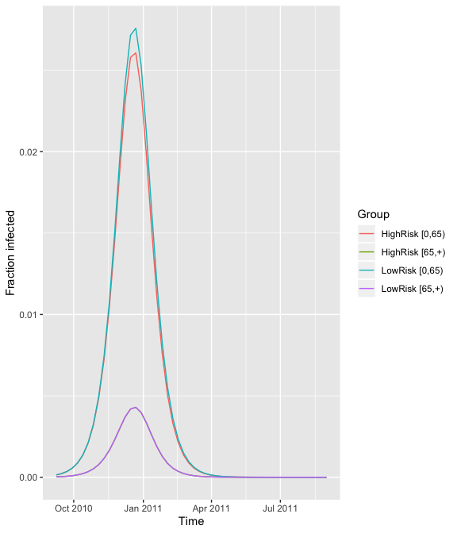

```r
library(ggplot2)

odes <- infection_odin(population, initial.infected, vaccine_calendar, contacts,
               c(0.7, 0.3), 0.17, c(0.8, 1.8), 7)

fraction.infected <- odes %>%
  gather(Group, Incidence, -Time) %>%
  mutate(fraction = Incidence/population[Group])

ggplot( data=fraction.infected ) + geom_line( aes(x=Time, y=fraction, colour = Group) ) +
  ylab( "Fraction infected" )
```

# Further reading

The next step now is to use your new model in the parameter inference. How to do this is explained in more detail in the [inference vignette](https://blackedder.github.io/flu-evidence-synthesis/inference.html).

## Possible exercises

1. Smooth the vaccination function instead of using a step function
2. Make it possible to use different contact matrices for different time periods
3. Simplify it to use SEIR/SIR instead of the SEEIIR model shown here

Baguelin, Marc, Stefan Flasche, Anton Camacho, Nikolaos Demiris, Elizabeth Miller, and W. John Edmunds. 2013. “Assessing Optimal Target Populations for Influenza Vaccination Programmes: An Evidence Synthesis and Modelling Study.” *PLoS Med* 10 (10): e1001527. https://doi.org/10.1371/journal.pmed.1001527.